# Ejercicio 4. Materiales

Pag 26. Everest. TINII

Aurelio Gallardo Rodríguez

9 de junio de 2017

# Enunciado Ejercicio 4

Una barra elástica de acero, con un límite elástico de $5000kp/cm^{2}$,es sometida a una fuerza de tracción $8500kp$. Sabiendo que la longitud de la barra de acero es de 400mm, y su módulo de elasticidad $E=2.1\cdot10^{6}kp/cm^{2}$, calcular el diámetro de la barra para que su alargamiento total no supere las 50 centésimas de milímetro.

# Cálculos en el límite elástico.

En el punto del límite elástico, sabemos que $\sigma_{e}=E\cdot\epsilon_{e}$ luego, podemos calcular el alargamiento como…

$\epsilon_{e}=\sigma_{e} / E = \frac{5000 \cdot kp/cm^2}{2.1\times 10^{6} \cdot kp/cm^2} = 0.002381$

Y de aquí, $\Delta L = \epsilon_ {e} \cdot L_{0} = 0.002381 \cdot 400 mm = 0.952381 \cdot mm$

# En el punto problema

Calculamos ahora el punto problema. Sabemos que tenemos un alargamiento máximo de $\Delta L_{x}=0.5 \cdot mm$

Alargamiento –> $\epsilon_{x}=\frac{\Delta L_{x}}{L0}= \frac{0.5 \cdot mm}{400 \cdot mm} = 0.00125$

Tensión –> $\sigma_ {x} = \epsilon_{x} \cdot E = 0.00125\cdot 2.1\times 10^{6} \cdot kp/cm^2 = 2625 \cdot kp/cm^2$

Superficie –> $S_{0} = F / \sigma_ {x} = 8500 \cdot kp / 2625 \cdot kp/cm^2 = 3.24 \cdot cm^2$

Diámetro –> $\Phi=\sqrt{\frac{4 \cdot S_{0}}{\pi}}=\sqrt{\frac{4 \cdot 3.24 \cdot cm^2}{\pi}}= 2.03 \cdot cm$

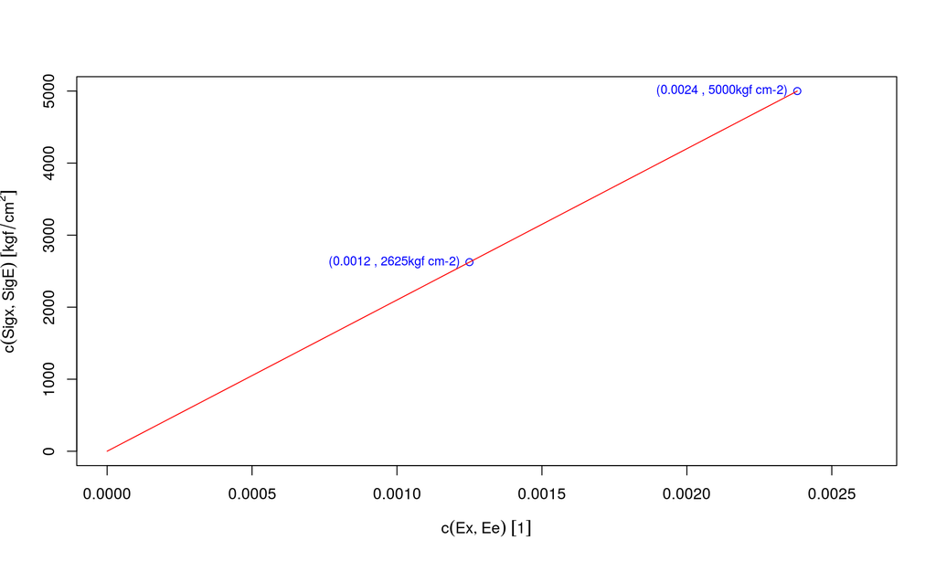